# PROJECT - NEURAL NETWORKS

# PART 2

#### Neural Network Classifier for the same data set

No need to repeat the data analysis and visualization, since performing on same dataset

```python
# Step: Split the parameters from the Signal Strength

X = df.drop('Signal_Strength', axis=1)
y = df['Signal_Strength']

# Based on the analysis that we did previously, we know that the target column has 6 values (3, 4, 5, 6, 7, 8)
# For classification, lets convert the values to one hot vectors (dummy variables)

# One hot encoding

# encoder = LabelEncoder()
# encoder.fit(y)
# encoded_y = encoder.transform(y)
dummy_y = pd.get_dummies(y)

# Splitting the dataset into Training and Testing
X_train, X_test, y_train, y_test = train_test_split(X, dummy_y, test_size = 0.3, random_state = 5)


# Display shapes
print(X_train.shape)
print(X_test.shape)
print(y_train.shape)
print(y_test.shape)
```

```
(1119, 11)
(480, 11)
(1119, 6)
(480, 6)
```

```python
# Oversampling the training data to address imbalanced classes issue
oversampler = SMOTE(random_state=5)
X_train_over , y_train_over = oversampler.fit_resample(X_train , y_train.values)
```

### Model Building

**`Key Note:`**

- `I will try models using original dataset as well as dataset with imbalanced classes addressed (using SMOTE)`

```python
# Initializing the model
model_C = Sequential()

# Building the model
# Add layer, input size = 11
model_C.add(Dense(128,  kernel_initializer='normal', input_dim=11))
model_C.add(BatchNormalization())
model_C.add(Activation("relu"))

model_C.add(Dense(64, kernel_initializer='normal'))
model_C.add(BatchNormalization())
model_C.add(Activation("relu"))

model_C.add(Dense(32, kernel_initializer='normal'))
model_C.add(BatchNormalization())
model_C.add(Activation("relu"))

model_C.add(Dense(16, kernel_initializer='normal'))
model_C.add(BatchNormalization())
model_C.add(Activation("relu"))

# Add output layer, 6 output neurons as we are doing 6 class classification
model_C.add(Dense(6, activation = 'softmax', kernel_initializer='normal'))
```

```python
# Compile & Fit
model_C.compile(optimizer='sgd', loss='categorical_crossentropy', metrics=['accuracy'])
model_C.fit(X_train, y_train,
          validation_data=(X_test, y_test),
          epochs=100,
          batch_size=32)
```

```
<tensorflow.python.keras.callbacks.History at 0x7fde595ba520>
```

```python
# Review model summary
model_C.summary()
```

```
Model: "sequential_2"
_________________________________________________________________
Layer (type)                 Output Shape              Param #
=================================================================
dense_11 (Dense)             (None, 128)               1536
_________________________________________________________________
batch_normalization_9 (Batch (None, 128)               512
_________________________________________________________________
activation_9 (Activation)    (None, 128)               0
_________________________________________________________________
dense_12 (Dense)             (None, 64)                8256
_________________________________________________________________
batch_normalization_10 (Batc (None, 64)                256
_________________________________________________________________
activation_10 (Activation)   (None, 64)                0
_________________________________________________________________
dense_13 (Dense)             (None, 32)                2080
_________________________________________________________________
batch_normalization_11 (Batc (None, 32)                128
_________________________________________________________________
activation_11 (Activation)   (None, 32)                0
_________________________________________________________________
dense_14 (Dense)             (None, 16)                528
_________________________________________________________________
batch_normalization_12 (Batc (None, 16)                64
_________________________________________________________________
activation_12 (Activation)   (None, 16)                0
_________________________________________________________________
dense_15 (Dense)             (None, 6)                 102
=================================================================
Total params: 13,462
Trainable params: 12,982
Non-trainable params: 480
_________________________________________________________________
```

```python
model_C.evaluate(X_train, y_train)
```

```
[0.98220294713974, 0.5647900104522705]
```

```python
# How model performed?

y_pred = model_C.predict(X_test)
model_C.evaluate(X_test,y_test)
```

```
[1.0806626081466675, 0.53125]
```

##### Running model with Adam optimizer

```python
# Initializing the model
model_C_1 = Sequential()

# Building the model
# Add layer, input size = 11
model_C_1.add(Dense(128,  kernel_initializer='normal', input_dim=11))
model_C_1.add(BatchNormalization())
model_C_1.add(Activation("relu"))

model_C_1.add(Dense(64, kernel_initializer='normal'))
model_C_1.add(BatchNormalization())
model_C_1.add(Activation("relu"))

model_C_1.add(Dense(32, kernel_initializer='normal'))
model_C_1.add(BatchNormalization())
model_C_1.add(Activation("relu"))

model_C_1.add(Dense(16, kernel_initializer='normal'))
model_C_1.add(BatchNormalization())
model_C_1.add(Activation("relu"))

# Add output layer, 6 output neurons as we are doing 6 class classification
model_C_1.add(Dense(6, activation = 'softmax', kernel_initializer='normal'))
```

```python
# Compile and Fit

model_C_1.compile(optimizer='adam', loss='categorical_crossentropy', metrics=['accuracy'])
model_C_1.fit(X_train, y_train,
          validation_data=(X_test, y_test),
          epochs=100,
          batch_size=32)
```

```
<tensorflow.python.keras.callbacks.History at 0x7fde74db87f0>
```

```python
model_C_1.evaluate(X_train, y_train)
```

```
[0.5841881632804871, 0.7569258213043213]
```

```python
model_C_1.evaluate(X_test, y_test)
```

```
[1.1037274599075317, 0.606249988079071]
```

### Running NN on oversampled data

```python
# Initializing the model
model_C_2 = Sequential()

# Building the model
# Add layer, input size = 11
model_C_2.add(Dense(128,  kernel_initializer='normal', input_dim=11))
model_C_2.add(BatchNormalization())
model_C_2.add(Activation("relu"))

model_C_2.add(Dense(64, kernel_initializer='normal'))
model_C_2.add(BatchNormalization())
model_C_2.add(Activation("relu"))

model_C_2.add(Dense(32, kernel_initializer='normal'))
model_C_2.add(BatchNormalization())
model_C_2.add(Activation("relu"))

model_C_2.add(Dense(16, kernel_initializer='normal'))
model_C_2.add(BatchNormalization())
model_C_2.add(Activation("relu"))

# Add output layer, 6 output neurons as we are doing 6 class classification
model_C_2.add(Dense(6, activation = 'softmax', kernel_initializer='normal'))
```

```python
# Compile and Fit

model_C_2.compile(optimizer='sgd', loss='categorical_crossentropy', metrics=['accuracy'])
model_C_2.fit(X_train_over, y_train_over, validation_data=(X_test, y_test), epochs=100, batch_size=32)
```

```
<tensorflow.python.keras.callbacks.History at 0x7fde5b88c220>
```

```python
model_C_2.evaluate(X_train_over, y_train_over)
```

```
[0.870853841304779, 0.6623931527137756]
```

```python
model_C_2.evaluate(X_test, y_test)
```

```
[1.3573955297470093, 0.4625000059604645]
```

##### Running model with Adam optimizer

```python
# Initializing the model
model_C_3 = Sequential()

# Building the model
# Add layer, input size = 11
model_C_3.add(Dense(128,  kernel_initializer='normal', input_dim=11))
model_C_3.add(BatchNormalization())
model_C_3.add(Activation("relu"))

model_C_3.add(Dense(64, kernel_initializer='normal'))
model_C_3.add(BatchNormalization())
model_C_3.add(Activation("relu"))

model_C_3.add(Dense(32, kernel_initializer='normal'))
model_C_3.add(BatchNormalization())
model_C_3.add(Activation("relu"))

model_C_3.add(Dense(16, kernel_initializer='normal'))
model_C_3.add(BatchNormalization())
model_C_3.add(Activation("relu"))

# Add output layer, 6 output neurons as we are doing 6 class classification
model_C_3.add(Dense(6, activation = 'softmax', kernel_initializer='normal'))
```

```python
# Compile and Fit

model_C_3.compile(optimizer='adam', loss='categorical_crossentropy', metrics=['accuracy'])
model_C_3.fit(X_train_over, y_train_over, validation_data=(X_test, y_test), epochs=100, batch_size=32)
```

```
<tensorflow.python.keras.callbacks.History at 0x7fde5ae25a90>
```

```python
model_C_3.evaluate(X_train_over, y_train_over)
```

```
[0.34900957345962524, 0.8668091297149658]
```

```python
model_C_3.evaluate(X_test, y_test)
```

```
[1.483432412147522, 0.5208333134651184]
```

```python
# Getting predictions for the best model
y_pred = model_C_1.predict(X_test)
```

##### Pickle the NN Classifier

```python
# Creating JSON format string with model details
model_json = model_C_1.to_json()

# Write string into JSON file
with open("model_clf.json", "w") as loaded_json:
    loaded_json.write(model_json)
# Save model weights
model_C_1.save_weights("nn_clf_weights.h5")
```

##### Reloading the pickled model

```python
loaded_json_file = open("model_clf.json")
clf_json = loaded_json_file.read()
loaded_clf = model_from_json(clf_json)
loaded_clf.load_weights("nn_clf_weights.h5")
```

```python
y_pred_loaded = loaded_clf.predict(X_test)
```

```python
(y_pred_loaded == y_pred).all()
```

```
True
```

`Every prediction from the loaded model is the same as original model`

```python
# Let's predict a few datapoints...
print("Predictions:")
print(y_pred_loaded[123].argmax()+3, "-> Index 123")
print(y_pred_loaded[456].argmax()+3, "-> Index 456")
print()
print("Actuals:")
print(y_test.iloc[123], "-> Index 123")
print(y_test.iloc[456], "-> Index 456")
```

```
Predictions:
6 -> Index 123
7 -> Index 456

Actuals:
3    0
4    0
5    0
6    1
7    0
8    0
Name: 1190, dtype: uint8 -> Index 123
3    0
4    0
5    0
6    0
7    1
8    0
Name: 1157, dtype: uint8 -> Index 456
```

# Part 3

```python
import tkinter as tk
from tkinter import ttk
import re
import pandas as pd
from tensorflow.keras.models import Sequential
from tensorflow.keras.layers import Dense
from tensorflow.keras.layers import BatchNormalization
from tensorflow.keras.layers import Activation

window = tk.Tk()
window.title = "Neural Network GUI -> By Aryan Jain"
fn = ttk.Label(window, text="Enter dataset file name: ")
fn.grid(row=0, column=0, sticky=tk.W)
file_name = tk.StringVar()
file_name_entry=ttk.Entry(window,textvariable=file_name)
file_name_entry.grid(row=0,column=1)

def import_data():
    global df
    df_file_name = file_name.get()
    file_format = re.findall(r"{.}+", df_file_name)
    if file_format == ".xlsx":
        df = pd.read_excel(df_file_name)
    elif file_format == ".csv":
        df = pd.read_csv(file_name)
    read_data = ttk.Entry()
    read_data.grid(row=0, column=3)
    read_data.insert(0, "Dataset has been read")

import_data_button = tk.Button(window, text="Click to import selected dataset", command=import_data)
import_data_button.grid(row=0, column=2)


tgt_var = ttk.Label(window, text="Enter target variable name: ")
tgt_var.grid(row=1, column=0, sticky=tk.W)
target = tk.StringVar()
target_entry=ttk.Entry(window,textvariable=target)
target_entry.grid(row=1,column=1)

def get_target_var():
    global X
    global y
    df_target = target.get()
    try:
        df_target = str(df_target)
        X = df.drop(df_target, axis=1)
        y = df[df_target]
        tgt_found_str = "Found inputted target variable"
    except:
        tgt_found_str = "Invalid target variable"

    tgt_found = ttk.Entry()
    tgt_found.grid(row=1, column=3)
    tgt_found.insert(0, tgt_found_str)

find_tgt_button = tk.Button(window, text="Click to set selected variable as target", command=get_target_var)
find_tgt_button.grid(row=1, column=2)


nn_regr_text = ttk.Label(window, text="Neural Network Regression: ")
nn_regr_text.grid(row=2, column=0, sticky=tk.W)

def build_nn_regr():
    global nn_regr
    build_nn = ttk.Label(window, text="Building NN model...")
    build_nn.grid(row=4, column=1)
    nn_regr = Sequential()
    nn_regr.add(Dense(128, kernel_initializer="normal", input_dim=X.shape[1]))
    nn_regr.add(BatchNormalization())
    nn_regr.add(Activation('relu'))

    nn_regr.add(Dense(64, kernel_initializer="normal"))
    nn_regr.add(BatchNormalization())
    nn_regr.add(Activation('relu'))

    nn_regr.add(Dense(32, kernel_initializer="normal"))
    nn_regr.add(BatchNormalization())
    nn_regr.add(Activation('relu'))

    nn_regr.add(Dense(16, kernel_initializer="normal"))
    nn_regr.add(BatchNormalization())
    nn_regr.add(Activation('relu'))

    nn_regr.add(Dense(8, kernel_initializer="normal"))
    nn_regr.add(BatchNormalization())
    nn_regr.add(Activation('relu'))

    nn_regr.add(Dense(128, kernel_initializer="normal", activation="linear"))
    nn_regr.compile(optimizer="adam", loss="mse")
    build_nn.configure(text="NN Built")

build_model = tk.Button(window, text="Build model with layers", command=build_nn_regr)
build_model.grid(row=3, column=1)

def train_nn_regr():
    fit_nn = ttk.Label(window, text="Fitting NN model for 100 epochs...")
    fit_nn.grid(row=4, column=2)
    nn_regr.fit(X, y, 32, 100)
    fit_nn.configure(text="Fitted NN regressor")

train_model = tk.Button(window, text="Train NN Regressor", command=train_nn_regr)
train_model.grid(row=3, column=2)


def pickle_nn_regr():
    pickle_nn = ttk.Label(window, text="Pickling NN model...")
    pickle_nn.grid(row=4, column=3)
    # Creating JSON format string with model details
    model_json = nn_regr.to_json()

    # Write string into JSON file
    with open("model_regr_gui.json", "w") as loaded_json:
        loaded_json.write(model_json)
    # Save model weights
    nn_regr.save_weights("nn_regr_gui_weights.h5")
    pickle_nn.configure(text="NN Regressor has been pickled")

pickle_model = tk.Button(window, text="Pickle Model", command=pickle_nn_regr)
pickle_model.grid(row=3, column=3)

def get_score():
    score_nn = ttk.Label(window, text="Getting score for the model")
    score_nn.grid(row=4, column=4)
    nn_mse = nn_regr.evaluate(X, y)
    score_nn.configure(text=f"MSE score for this NN on given data is {round(nn_mse, 2)}")
score_model = tk.Button(window, text="Score Model", command=get_score)
score_model.grid(row=3, column=4)



nn_clf_text = ttk.Label(window, text="Neural Network Classification: ")
nn_clf_text.grid(row=5, column=0, sticky=tk.W)

def build_nn_clf():
    global nn_clf
    global y_clf
    y_clf = np_utils.to_categorical(y)
    build_nn = ttk.Label(window, text="Building NN model...")
    build_nn.grid(row=7, column=1)
    nn_clf = Sequential()
    nn_clf.add(Dense(128, kernel_initializer="normal", input_dim=X.shape[1]))
    nn_clf.add(BatchNormalization())
    nn_clf.add(Activation('relu'))

    nn_clf.add(Dense(64, kernel_initializer="normal"))
    nn_clf.add(BatchNormalization())
    nn_clf.add(Activation('relu'))

    nn_clf.add(Dense(32, kernel_initializer="normal"))
    nn_clf.add(BatchNormalization())
    nn_clf.add(Activation('relu'))

    nn_clf.add(Dense(16, kernel_initializer="normal"))
    nn_clf.add(BatchNormalization())
    nn_clf.add(Activation('relu'))

    nn_clf.add(Dense(8, kernel_initializer="normal"))
    nn_clf.add(BatchNormalization())
    nn_clf.add(Activation('relu'))

    nn_clf.add(Dense(9, kernel_initializer="normal", activation="softmax"))
    nn_clf.compile(optimizer="adam", loss="categorical_crossentropy", metrics=['accuracy'])
    build_nn.configure(text="NN Built")

build_model = tk.Button(window, text="Build model with layers", command=build_nn_clf)
build_model.grid(row=6, column=1)

def train_nn_clf():
    fit_nn = ttk.Label(window, text="Fitting NN model for 100 epochs...")
    fit_nn.grid(row=7, column=2)
    nn_clf.fit(X, y_clf, 32, 100)
    fit_nn.configure(text="Fitted NN classifier")

train_model = tk.Button(window, text="Train NN Classifier", command=train_nn_clf)
train_model.grid(row=6, column=2)




def pickle_nn_clf():
    pickle_nn = ttk.Label(window, text="Pickling NN model...")
    pickle_nn.grid(row=7, column=3)
    # Creating JSON format string with model details
    model_json = nn_regr.to_json()

    # Write string into JSON file
    with open("model_clf_gui.json", "w") as loaded_json:
        loaded_json.write(model_json)
    # Save model weights
    nn_regr.save_weights("nn_clf_gui_weights.h5")
    pickle_nn.configure(text="NN Regressor has been pickled")

pickle_model = tk.Button(window, text="Pickle Model", command=pickle_nn_clf)
pickle_model.grid(row=6, column=3)

def get_score():
    score_nn = ttk.Label(window, text="Getting score for the model")
    score_nn.grid(row=7, column=4)
    nn_ce, nn_acc = nn_clf.evaluate(X, y_clf)
    score_nn.configure(text=f"Cross Entropy score for this NN on given data is {round(nn_ce, 2)}")
score_model = tk.Button(window, text="Score Model", command=get_score)
score_model.grid(row=6, column=4)
window.mainloop()
```

#### PART 4

Read the h5py file and get the data

```python
# READ THE H5PY FILE

df_vh = h5py.File("Part - 4 - Autonomous_Vehicles_SVHN_single_grey1.h5",'r')
```

```python
# Display keys

df_vh.keys()
```

```
<KeysViewHDF5 ['X_test', 'X_train', 'X_val', 'y_test', 'y_train', 'y_val']>
```

```python
# Load the Training, Validation and Test set

X_train = df_vh['X_train'][:]
y_train = df_vh['y_train'][:]
X_val =   df_vh['X_val'][:]
y_val =   df_vh['y_val'][:]
X_test =  df_vh['X_test'][:]
y_test =  df_vh['y_test'][:]

# Inspect the shapes

print(X_train.shape)
print(y_train.shape)
print(X_val.shape)
print(y_val.shape)
print(X_test.shape)
print(y_test.shape)
```

```
(42000, 32, 32)
(42000,)
(60000, 32, 32)
(60000,)
(18000, 32, 32)
(18000,)
```

```python
# Lets view the dataset by viewing the image and dumping the corresponding label.
```

```
7 2 9 0 9 1 8 4 4 8
9 1 4 3 5 8 6 5 5 0
6 5 8 3 2 0 1 9 5 2
8 9 1 0 9 5 3 3 7 6
4 2 4 9 6 7 8 8 3 5
3 7 1 4 8 1 4 2 9 0
1 5 9 9 2 2 2 4 8 9
8 3 8 4 5 2 8 6 4 5
4 2 8 2 4 0 9 9 6 3
2 7 5 0 7 6 9 8 7 2
```

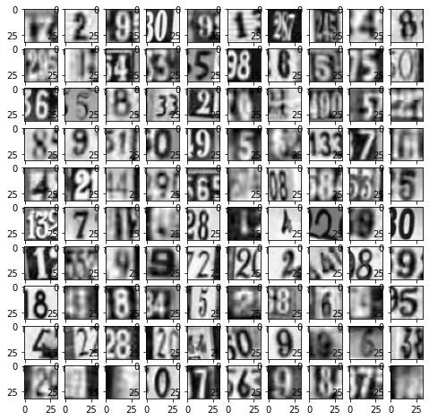

```python
import matplotlib.pyplot as plt
columns = 10
rows = 10

fig=plt.figure(figsize=(8, 8))

for i in range(1, columns*rows + 1):
    img = X_test[i]
    fig.add_subplot(rows, columns, i)
    print (y_test[i], end=' ')
    if i % columns == 0:
        print()
    plt.imshow(img, cmap='gray')

plt.show()
```

```python
#Let's find unique labels in the data set
print(np.unique(y_train))
print(np.unique(y_val))
print(np.unique(y_test))
```

```
[0 1 2 3 4 5 6 7 8 9]
[0 1 2 3 4 5 6 7 8 9]
[0 1 2 3 4 5 6 7 8 9]
```

The possible outputs / classes are all digits from 0-9

# Data Pre-processing

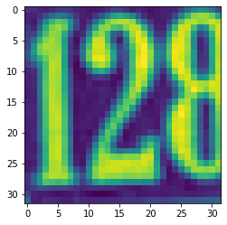

```
Label:  2
```

```python
plt.imshow(X_train[0])    # show first number in the dataset
plt.show()
print('Label: ', y_train[0])
```

```python
# reshaping X data: (n, 32, 32) => (n, 1024)
X_train = X_train.reshape((X_train.shape[0], -1))
X_val = X_val.reshape((X_val.shape[0], -1))
X_test = X_test.reshape((X_test.shape[0], -1))
print(X_train.shape, X_test.shape, X_val.shape)
```

```
(42000, 1024) (18000, 1024) (60000, 1024)
```

```python
# converting y data into categorical (one-hot encoding), here we have 10 classes , 0 to 9
from tensorflow.keras.utils import to_categorical

y_train = to_categorical(y_train)
y_val = to_categorical(y_val)
y_test = to_categorical(y_test)
print(y_train.shape, y_test.shape, y_val.shape)
```

```
(42000, 10) (18000, 10) (60000, 10)
```

```python
print('Label: ', y_train[0])
```

```
Label:  [0. 0. 1. 0. 0. 0. 0. 0. 0. 0.]
```

After one hot encoding, the label "2" is shown in the above manner.

# Normalize Data

We need to normalize our data before using in the NN models. Here as we are dealing with image, we can divide the pixel values by 255.

```python
print("Max value in X_train:", X_train.max())
print("Min value in X_train:", X_train.min())
```

```
Max value in X_train: 254.9745
Min value in X_train: 0.0
```

```python
X_train = X_train.astype('float32')
X_val = X_val.astype('float32')
X_test = X_test.astype('float32')

X_train /= 255
X_val /= 255
X_test /= 255
```

```python
print("Max value in X_train:", X_train.max())
print("Min value in X_train:", X_train.min())
```

```
Max value in X_train: 0.9999
Min value in X_train: 0.0
```

# Design, train, tune and test a neural network image classifier.

**Build a basic NN Model to start with**

Initialize a sequential model

- let's build a sequential model
- add 4 dense layers to start with

number of neurons in first layer: 512

number of neurons in second layer: 256

number of neurons in third layer: 128

number of neurons in last layer: number of possible outputs / classes ( 10 )

activation function in hidden layers: relu

activation function in last layer: softmax

```python
model = Sequential()
model.add(Dense(512, activation="relu", input_shape = (1024, )))
model.add(Dense(256, activation="relu"))
model.add(Dense(128, activation="relu"))
model.add(Dense(10, activation="softmax"))
```

**Compile and fit the model**

loss: "categorical_crossentropy"

metrics: "accuracy"

optimizer: "sgd"

```python
# Compile the model
model.compile(loss="categorical_crossentropy", metrics=["accuracy"], optimizer="sgd")

# Fit the model
model.fit(x=X_train, y=y_train, batch_size=32, epochs=10, validation_data=(X_val, y_val)) # keeping number of epochs as 10 execution time is high
```

```
<tensorflow.python.keras.callbacks.History at 0x7fde7689d460>
```

```python
# Evaluate the model on test data
model.evaluate(X_test, y_test)
```

```
[0.8629154562950134, 0.7366111278533936]
```

```python
model.summary()
```

```
Model: "sequential_6"
_________________________________________________________________
Layer (type)                 Output Shape              Param #
=================================================================
dense_31 (Dense)             (None, 512)               524800
_________________________________________________________________
dense_32 (Dense)             (None, 256)               131328
_________________________________________________________________
dense_33 (Dense)             (None, 128)               32896
_________________________________________________________________
dense_34 (Dense)             (None, 10)                1290
=================================================================
Total params: 690,314
Trainable params: 690,314
Non-trainable params: 0
_________________________________________________________________
```

Let's try a different weight initializer ( kernel initializer )

```python
model_1 = Sequential()
model_1.add(Dense(512, activation="relu", input_shape = (1024, ), kernel_initializer='he_normal'))
model_1.add(Dense(256, activation="relu", kernel_initializer='he_normal'))
model_1.add(Dense(128, activation="relu", kernel_initializer='he_normal'))
model_1.add(Dense(10, activation="softmax"))
```

```python
# Compile the model
model_1.compile(loss="categorical_crossentropy", metrics=["accuracy"], optimizer="sgd")

# Fit the model
model_1.fit(x=X_train, y=y_train, batch_size=32, epochs=10, validation_data=(X_val, y_val))
```

```
<tensorflow.python.keras.callbacks.History at 0x7fde7689db20>
```

```python
# Evaluate the model on test data
model_1.evaluate(X_test, y_test)
```

```
[1.0488653182983398, 0.6742222309112549]
```

Lets try and use Batch Normalization

```python
model_2 = Sequential()
model_2.add(Dense(512, input_shape = (1024, ), kernel_initializer='he_normal'))
model_2.add(BatchNormalization())
model_2.add(Activation('relu'))
model_2.add(Dense(256, kernel_initializer='he_normal'))
model_2.add(BatchNormalization())
model_2.add(Activation('relu'))
model_2.add(Dense(128, kernel_initializer='he_normal'))
model_2.add(BatchNormalization())
model_2.add(Activation('relu'))
model_2.add(Dense(10, activation="softmax"))
```

```python
# Compile the model
model_2.compile(loss="categorical_crossentropy", metrics=["accuracy"], optimizer="sgd")

# Fit the model
model_2.fit(x=X_train, y=y_train, batch_size=32, epochs=10, validation_data=(X_val, y_val))
```

```
<tensorflow.python.keras.callbacks.History at 0x7fde35f59310>
```

```python
# Evaluate the model on test data
model_2.evaluate(X_test, y_test)
```

```
[1.0253585577011108, 0.6756666898727417]
```

Lets try dropout to see if it helps improve accuracy

```python
model_3 = Sequential()
model_3.add(Dense(512, input_shape = (1024, ), kernel_initializer='he_normal'))
model_3.add(BatchNormalization())
model_3.add(Activation('relu'))
model_3.add(Dropout(0.2))
model_3.add(Dense(256, kernel_initializer='he_normal'))
model_3.add(BatchNormalization())
model_3.add(Activation('relu'))
model_3.add(Dropout(0.2))
model_3.add(Dense(128, kernel_initializer='he_normal'))
model_3.add(BatchNormalization())
model_3.add(Activation('relu'))
model_3.add(Dropout(0.2))
model_3.add(Dense(10, activation="softmax"))
```

```python
# Compile the model
model_3.compile(loss="categorical_crossentropy", metrics=["accuracy"], optimizer="sgd")

# Fit the model
model_3.fit(x=X_train, y=y_train, batch_size=32, epochs=10, validation_data=(X_val, y_val))
```

```
<tensorflow.python.keras.callbacks.History at 0x7fde2600c400>
```

```python
# Evaluate the model on test data
model_3.evaluate(X_test, y_test)
```

```
[0.746169924736023, 0.7724999785423279]
```

Based on the above, 'model_3' seems to give us the best results. Lets continue with this model.

# Plot the training loss, validation loss vs number of epochs and training accuracy, validation accuracy vs number of epochs plot

```python
history = model_3.fit(x=X_train, y=y_train, batch_size=32, epochs=100, validation_data=(X_val, y_val)) # this time instead of 10 epochs, running 100 epochs
```

```python
# Evaluate the model on test data
model_3.evaluate(X_test, y_test)
```

```
[0.6399024724960327, 0.8096666932106018]
```

As we see, after taraining for more number of epochs ,the accuracy has increased to almost 80% on test data( accuracies on training and validation data also increased significantly )

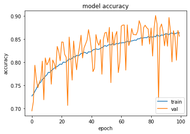

```python
plt.plot(history.history['accuracy'])
plt.plot(history.history['val_accuracy'])
plt.title('model accuracy')
plt.ylabel('accuracy')
plt.xlabel('epoch')
plt.legend(['train', 'val'], loc='lower right')
plt.show()
```

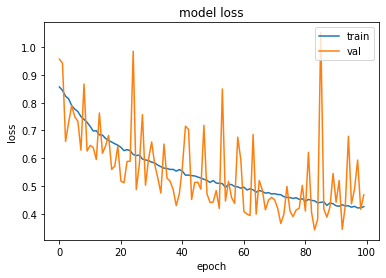

```python
plt.plot(history.history['loss'])
plt.plot(history.history['val_loss'])
plt.title('model loss')
plt.ylabel('loss')
plt.xlabel('epoch')
plt.legend(['train', 'val'], loc='upper right')
plt.show()
```

**`OBSERVATIONS:`**

- `The training accuracy is increasing with epochs and validation accuracy fluctuates a lot but then seems to overall have an upward trend.`
- `The training loss seems to reduce with the epochs and the validation loss seems to fluctuate a lot but again overall seems to have a downward trend.`
- `Also, here the validation loss and accuracy , on an average seem to be away from the training loss and accuracy.`

```python
# Using below to check execution time (used at he start of this notebook and at the end)
now = datetime.datetime.now()
print(f"Ending Time: {now.hour}:{now.minute}")
```

```
Ending Time: 12:51
```